# Reproducible Research: Peer Assessment 1

Boriana Valentinova Sunday, October 18, 2015

## Loading and preprocessing the data

```r
activity<- read.csv("activity.csv", header=T, sep=",",
                    colClasses=c("numeric", "character", "numeric"))
head(activity)
```

```
##   steps       date interval
## 1    NA 2012-10-01        0
## 2    NA 2012-10-01        5
## 3    NA 2012-10-01       10
## 4    NA 2012-10-01       15
## 5    NA 2012-10-01       20
## 6    NA 2012-10-01       25
```

```r
activity$date <- as.Date(activity$date, "%Y-%m-%d")
```

## What is mean total number of steps taken per day?

Calculate the total number of steps taken per day:

```r
total.steps <- aggregate(steps ~ date, data = activity, sum, na.rm = TRUE)
head(total.steps)
```

```
##         date steps
## 1 2012-10-02   126
## 2 2012-10-03 11352
## 3 2012-10-04 12116
## 4 2012-10-05 13294
## 5 2012-10-06 15420
## 6 2012-10-07 11015
```

Make a histogram of the total number of steps taken each day:

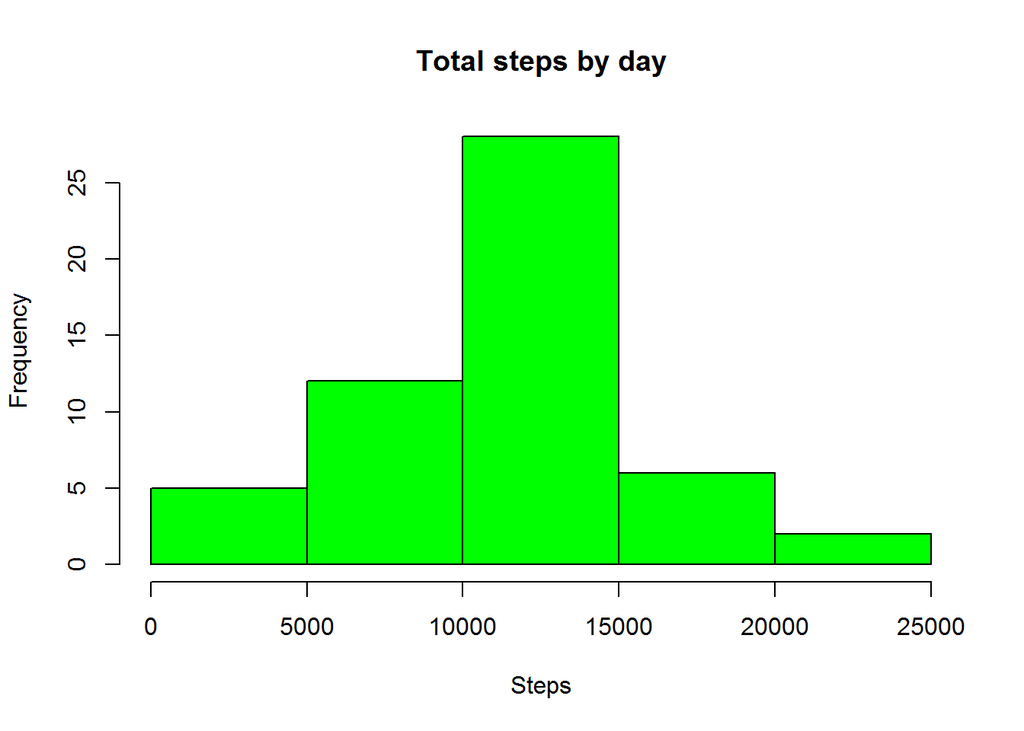

```r
hist(total.steps$steps, main = "Total steps by day", xlab = "Steps", col = "green")
```

Calculate and report the mean and median of the total number of steps taken per day:

```r
summary(total.steps$steps)
```

```
##    Min. 1st Qu.  Median    Mean 3rd Qu.    Max.
##      41    8841   10760   10770   13290   21190
```

```r
mean(total.steps$steps)
```

```
## [1] 10766.19
```

Make a time series plot (i.e. type = “l”) of the 5-minute interval (x-axis) and the average number of steps taken, averaged across all days (y-axis):

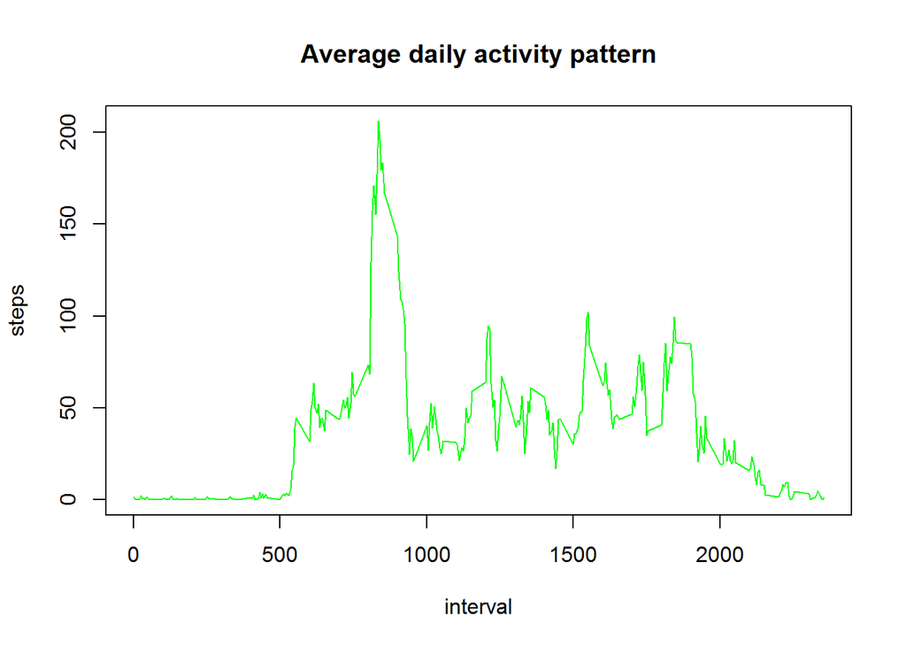

```r
interval.steps <- aggregate(steps ~ interval, data = activity, mean, na.rm =TRUE)
plot(interval.steps, main="Average daily activity pattern", type = "l", col = "green")
```

```r
interval.steps$interval[which.max(interval.steps$steps)]
```

```
## [1] 835
```

## Imputing missing values

Calculate and report the total number of missing values in the dataset:

```r
sum(is.na(activity$steps))
```

```
## [1] 2304
```

Devise a strategy for filling in all of the missing values in the dataset. The strategy does not need to be sophisticated. For example, you could use the mean/median for that day, or the mean for that 5-minute interval, etc.:

```r
na_positions <- which(is.na(activity$steps))
mean_positions <- rep(mean(activity$steps, na.rm=TRUE), times=length(na_positions))
```

Create a new dataset that is equal to the original dataset but with the missing data filled in:

```r
activity[na_positions, "steps"] <- mean_positions
sum(is.na(activity$steps))
```

```
## [1] 0
```

Make a histogram of the total number of steps taken each day and Calculate and report the mean and median total number of steps taken per day:

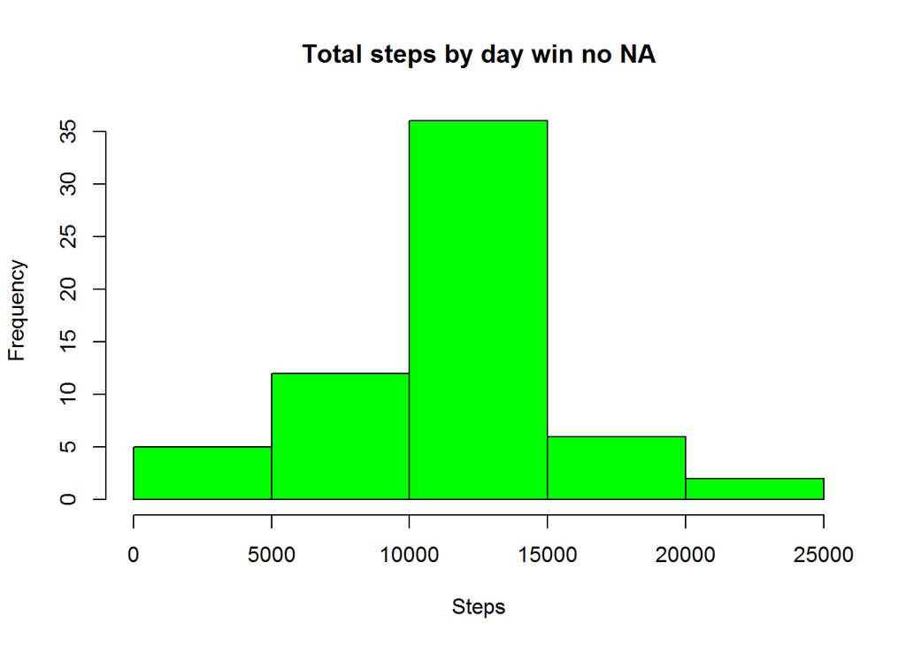

```r
total.steps <- aggregate(steps ~ date, data = activity, sum)
hist(total.steps$steps, main = "Total steps by day win no NA", xlab = "Steps", col = "green")
```

```r
summary(total.steps$steps)
```

```
##    Min. 1st Qu.  Median    Mean 3rd Qu.    Max.
##      41    9819   10770   10770   12810   21190
```

Do these values differ from the estimates from the first part of the assignment? No, they don’t. However, there is a 10 point change in the ylab which suggests more data.

What is the impact of imputing missing data on the estimates of the total daily number of steps? The shape of the histogram remains the same as the histogram from removed missing values. However, the frequency count is increased.

## Are there differences in activity patterns between weekdays and weekends?

Create a new factor variable in the dataset with two levels - “weekday” and “weekend” indicating whether a given date is a weekday or weekend day:

```r
day <- weekdays(as.Date(activity$date))
daylevel <- vector()
for (i in 1:nrow(activity)) {
        if (day[i] == "sábado") {
                daylevel[i] <- "Weekend"
                } else if (day[i] == "domingo") {
                        daylevel[i] <- "Weekend"
                        } else {
                                daylevel[i] <- "Weekday"
                                }
        }
activity$daylevel <- daylevel
activity$daylevel <- factor(activity$daylevel)
```

Make a panel plot containing a time series plot (i.e. type = “l”) of the 5-minute interval (x-axis) and the average number of steps taken, averaged across all weekday days or weekend days (y-axis):

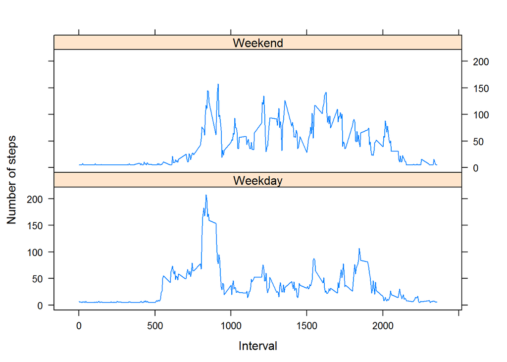

```r
library(lattice)
stepsByDay <- aggregate(steps ~ interval + daylevel, data = activity, mean)
names(stepsByDay) <- c("interval", "daylevel", "steps")
xyplot(steps ~ interval | daylevel, stepsByDay, type = "l", layout = c(1, 2),
       xlab = "Interval", ylab = "Number of steps")
```